**Machine Learning for Mechanical Engineering**  
**Homework 07 - Solution**

Instructor: Prof. Seungchul Lee  
http://iai.postech.ac.kr/  
Industrial AI Lab at POSTECH

# Problem 1

In statistics, it is important to understand the characteristics of population, sample and distributions.

```python
## uniform distribution
#
```

```python
## normal distribution
#
```

```python
## uniform distribution

Sample_N = 1000
```

4) Calculate covariance, covariance matrix and correlation coefficient with the below given data.

```python
x = np.random.normal(0, 0.3, 100)
data = np.array((x, 2 * x + np.random.normal(0, 0.5, 100)))

plt.figure(figsize = (8, 6))
plt.scatter(data[0], data[1])
plt.axis('equal')
plt.show()
```

```python
## write your code here
#
```

# Solution 1

In statistics, it is important to understand the characteristics of population, sample and distributions.

```python
import numpy as np
import matplotlib.pyplot as plt
%matplotlib inline
```

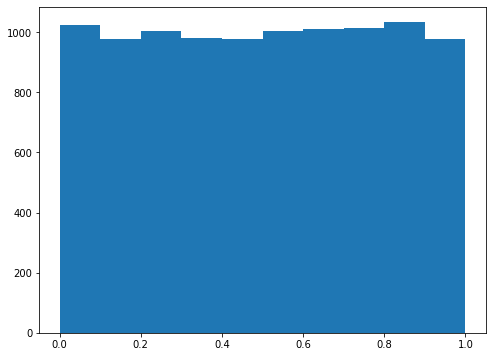

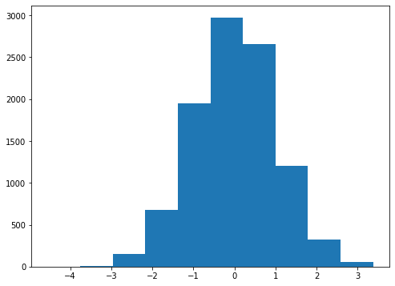

```python
## random number generation (1D)
m = 10000

uniform =  np.random.rand(m,1)
normal = np.random.randn(m,1)

plt.figure(figsize = (8,6))
plt.hist(uniform)
plt.show()

plt.figure(figsize = (8,6))
plt.hist(normal)
plt.show()
```

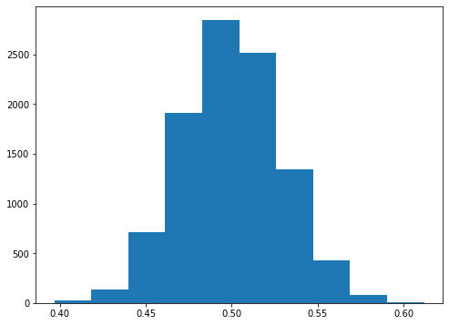

```python
# uniform distribution
n = 100
N = 10000
S = []
for i in range(N):
    index = np.random.randint(0, m, n)
    data = uniform[index]
    S.append(np.mean(data))

plt.figure(figsize = (8,6))
plt.hist(S)
plt.show()
```

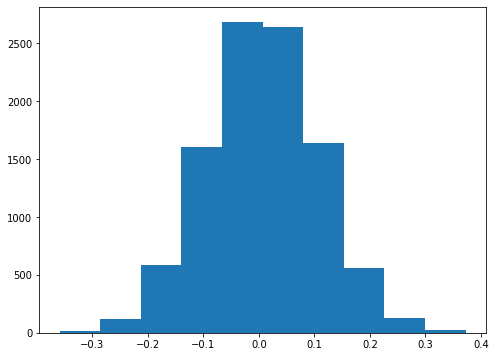

```python
# normal distribution
n = 100
N = 10000
S = []
for i in range(N):
    index = np.random.randint(0, m, n)
    data = normal[index]
    S.append(np.mean(data))

plt.figure(figsize = (8,6))
plt.hist(S)
plt.show()
```

3) With given data, calculate covariance, covariance matrix and correlation coefficient.

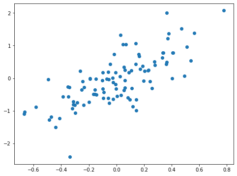

```python
x = np.random.normal(0, 0.3, 100)
data = np.array((x, 2 * x + np.random.normal(0, 0.5, 100)))

plt.figure(figsize = (8,6))
plt.scatter(data[0], data[1])
plt.show()
```

```python
# write your code here

cov = np.cov(data)

print(cov)
print('correlation coeff : ', cov[0,1] / np.sqrt(cov[0,0] * cov[1,1]))
```

```
[[0.08367784 0.16239738]
 [0.16239738 0.58173652]]
correlation coeff :  0.7360555929094487
```

# Problem 3

Download the data [reg_pca_data](https://www.dropbox.com/s/jes6kls021e6mm3/x_reg_and_y_reg_reg_pca.zip?dl=1), and plot datas in x, y plane.

```python
from six.moves import cPickle

x_reg = cPickle.load(open('./data_files/x_reg.pkl', 'rb'))
y_reg = cPickle.load(open('./data_files/y_reg.pkl', 'rb'))
```

1) Write a python code to conduct a linear regression (least square).

```python
## your code here
#
```

2) Write a python code to perform PCA. Since `mean(x) = mean(y) = 0`, the normalization step (mean subtraction and rescaling) can be skipped.

```python
## your code here
#
```

3) Plot both the regression line and the PCA line (i.e., the first principal component) at the same time, and comment on why the results are different.

```python
## your code here
#
```

# Solution 3

Download the data [reg_pca_data](https://www.dropbox.com/s/jes6kls021e6mm3/x_reg_and_y_reg_reg_pca.zip?dl=1), and plot datas in x, y plane.

```python
from six.moves import cPickle
import matplotlib.pyplot as plt
import cvxpy as cvx
import numpy as np

x_reg = cPickle.load(open('./data_files/x_reg.pkl', 'rb'))
y_reg = cPickle.load(open('./data_files/y_reg.pkl', 'rb'))
```

1) Write a python code to conduct a linear regression (least square).

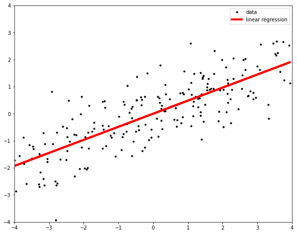

```python
x_reg = x_reg.reshape(-1, 1)
y_reg = y_reg.reshape(-1, 1)
ones_col = np.ones((x_reg.size, 1))
phi = np.hstack([x_reg, ones_col])

w = cvx.Variable((2,1))
objective = cvx.Minimize(cvx.sum_squares(phi * w - y_reg))
prob = cvx.Problem(objective)
prob.solve()
w = w.value

plt.figure(figsize = (10, 8))
plt.plot(x_reg, y_reg, 'k.', label = 'data')
plt.plot(x_reg, x_reg * w[0] + np.ones((200, 1)) * w[1], color = 'red', label = 'linear regression', linewidth = 4.0)
plt.xlim(-4,4)
plt.ylim(-4,4)
plt.legend()
plt.show()
```

2) Write a python code to perform PCA. Since `mean(x) = mean(y) = 0`, normalization step (mean subtraction and rescaling) can be skipped.

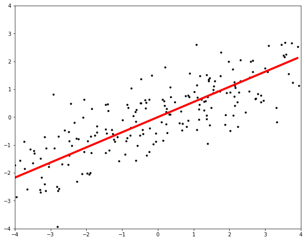

```python
num_data = x_reg.size
data = np.hstack([x_reg, y_reg])
data = np.asmatrix(data)
S = 1 / (num_data - 1) * data.T * data

D, V = np.linalg.eig(S)
idx = np.argsort(-D)
D = D[idx]; V = V[:, idx]
h = V[1, 0] / V[0, 0]
xp = np.arange(-4, 4, 0.1)
yp = h * xp;

plt.figure(figsize = (10, 8))
plt.plot(x_reg, y_reg, 'k.')
plt.plot(xp, yp, 'r', linewidth = 4.0)
plt.xlim(-4,4)
plt.ylim(-4,4)
plt.show()
```

3) Plot both the regression line and the PCA line at the same time.

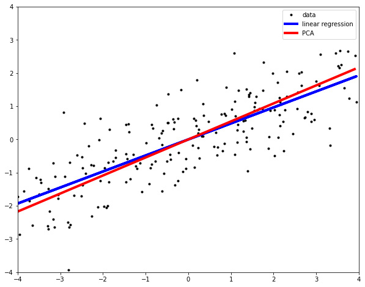

```python
fig = plt.figure(figsize = (10, 8))
plt.plot(x_reg, y_reg, 'k.', label = 'data')
plt.plot(x_reg, x_reg * w[0] + np.ones((200, 1)) * w[1], 'b', linewidth = 4.0, label = 'linear regression')
plt.plot(xp, yp, 'r', linewidth = 4.0, label = 'PCA')
plt.xlim(-4,4)
plt.ylim(-4,4)
plt.legend()
plt.show()
```

# Problem 4

[Show that minimizing the sum of squared errors maximizes the variance in the PCA.

# Solution 4

- Error between projected data in line and training data

\begin{align*} \lVert e^{(i)} \rVert ^2 & = \lVert x^{(i)} \rVert ^2 - \big( {x^{(i)}}^Tu \big)^2 \\ & = \lVert x^{(i)} \rVert ^2 - \big( {x^{(i)}}^Tu \big)^T\big( {x^{(i)}}^Tu \big) \\ & = \lVert x^{(i)} \rVert ^2 - u^Tx^{(i)}{x^{(i)}}^Tu\\ \end{align*}

$$\begin{align*} \frac {1}{m} \sum\limits_{i=1}^{m} \lVert e^{(i)} \rVert ^2 & = \frac {1}{m} \sum\limits_{i=1}^{m} \lVert x^{(i)} \rVert ^2 - \frac{1}{m}\sum\limits_{i=1}^{m}u^Tx^{(i)}{x^{(i)}}^Tu \\ & = \frac {1}{m} \sum\limits_{i=1}^{m} \lVert x^{(i)} \rVert ^2 - u^T\left(\frac{1}{m}\sum\limits_{i=1}^{m}x^{(i)}{x^{(i)}}^T\right)u \end{align*}$$

- Variance of projected data

$$\begin{align*} \text{variance of projected data} & = \frac{1}{m}\sum\limits_{i=1}^{m}\big(u^Tx^{(i)}\big)^2 = \frac{1}{m}\sum\limits_{i=1}^{m}\big( {x^{(i)}}^Tu\big)^2 \\ & = \frac{1}{m}\sum\limits_{i=1}^{m}\big( {x^{(i)}}^Tu\big)^T\big( {x^{(i)}}^Tu\big) = \frac{1}{m}\sum\limits_{i=1}^{m}u^Tx^{(i)}{x^{(i)}}^Tu \\ & = u^T\left(\frac{1}{m}\sum\limits_{i=1}^{m}x^{(i)}{x^{(i)}}^T \right) u \\ \end{align*}$$

- In an optimization form

$$\begin{align*} &\text{minimize} \; \underbrace{\frac {1}{m} \sum\limits_{i=1}^{m} \lVert x^{(i)} \rVert ^2}_{\text{constant given $x_i$}} - \underbrace{u^T\left(\frac{1}{m}\sum\limits_{i=1}^{m}x^{(i)}{x^{(i)}}^T\right)u}_{\text{maximize}} \\ \\ \implies &\text{maximize} \; u^T\left(\frac{1}{m}\sum\limits_{i=1}^{m}x^{(i)}{x^{(i)}}^T\right)u\end{align*}$$

$$ \therefore \; \text{minimize} \; error^2 = \text{maximize} \; variance$$

# Problem 6

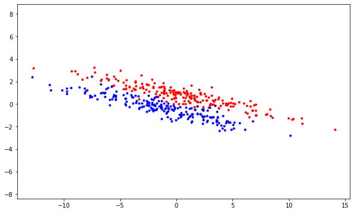

```python
import numpy as np
import random
import matplotlib.pyplot as plt

%matplotlib inline
n0 = 200
n1 = 200

sigma = [[19, -4],
         [-4, 1]]

x0 = np.random.multivariate_normal([0.7,0.7], sigma, n0)        # data in class 0
x1 = np.random.multivariate_normal([-0.5,-0.5], sigma, n1)      # data in class 0

x0 = np.asmatrix(x0)
x1 = np.asmatrix(x1)

plt.figure(figsize = (10, 6))
plt.plot(x0[:,0], x0[:,1], 'r.')
plt.plot(x1[:,0], x1[:,1], 'b.')
plt.ylim([-8, 8])
plt.xlim([-14, 14])
plt.axis('equal')
plt.show()
```

1) Plot the projection line from Fisher Discriminant Analysis.

```python
## your code here
#
```

2) Plot the projection line from PCA (i.e., the first principal component). In the case of PCA, you do not need to consider labels.(*i.e.* data class)

```python
## your code here
#
```

# Solution 6

1) Solve the problem with Fisher Discriminant Analysis and plot the projection line.

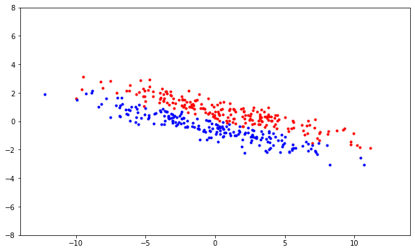

```python
import numpy as np
import random
import matplotlib.pyplot as plt

%matplotlib inline
n0 = 200
n1 = 200

sigma = [[19, -4],
         [-4, 1]]

x0 = np.random.multivariate_normal([0.7,0.7], sigma, n0)        # data in class 0
x1 = np.random.multivariate_normal([-0.5,-0.5], sigma, n1)      # data in class 0

x0 = np.asmatrix(x0)
x1 = np.asmatrix(x1)

plt.figure(figsize = (10, 6))
plt.plot(x0[:,0], x0[:,1], 'r.')
plt.plot(x1[:,0], x1[:,1], 'b.')
plt.ylim([-8, 8])
plt.xlim([-14, 14])
plt.show()
```

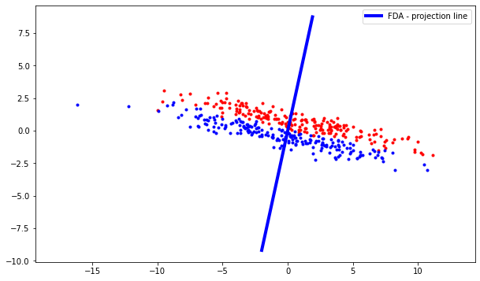

```python
x0 = np.asmatrix(x0)
x1 = np.asmatrix(x1)

mu0 = np.mean(x0, axis = 0)
mu1 = np.mean(x1, axis = 0)
S0 = 1 / (n0 - 1) * (x0 - mu0).T * (x0 - mu0)
S1 = 1 / (n1 - 1) * (x1 - mu1).T * (x1 - mu1)

w = (n0 * S0 + n1 * S1).I * (mu0 - mu1).T
h = w[1] / w[0]
xp = np.arange(-2, 2, 0.1)
yp = (h * xp).reshape(-1, 1)

plt.figure(figsize = (10, 6))
plt.plot(x0[:,0], x0[:,1], 'r.')
plt.plot(x1[:,0], x1[:,1], 'b.')
plt.plot(xp, yp, 'b', linewidth = 4.0, label = 'FDA - projection line')
plt.legend()
plt.axis('equal')
plt.show()
```

2) Solve the above problem with PCA and plot the projection line. In the case of PCA, you do not need to consider labels.(*i.e.* data class)

```python
X = np.vstack([x0.T, x1.T])
m = X.shape[0]

S = 1/(m-1)*X.T*X
S = np.asmatrix(S)

D, V = np.linalg.eig(S)

idx = np.argsort(-D)
D = D[idx]
V = V[:,idx]

y_pca = V[1,0]/V[0,0]*X
```

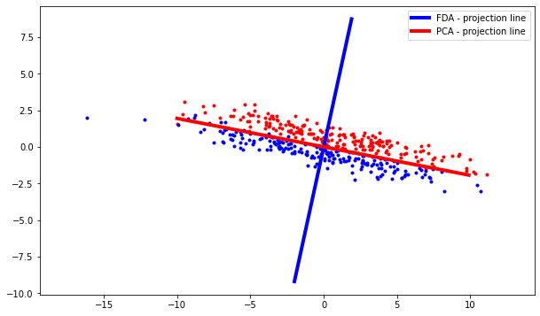

```python
data = np.vstack([x0, x1])
data = np.asmatrix(data)
num_data = data.shape[0]
S = 1 / (num_data - 1) * data.T * data

D, V = np.linalg.eig(S)
idx = np.argsort(-D)
D = D[idx]; V = V[:, idx]
h2 = V[1, 0] / V[0, 0]
xp2 = np.arange(-10, 10, 0.1)
yp2 = h2 * xp2

plt.figure(figsize = (10, 6))
plt.plot(x0[:,0], x0[:,1], 'r.')
plt.plot(x1[:,0], x1[:,1], 'b.')
plt.plot(xp, yp, 'b', linewidth = 4.0, label = 'FDA - projection line')
plt.plot(xp2, yp2, 'r', linewidth = 4.0, label = 'PCA - projection line')
plt.legend()
plt.axis('equal')
plt.show()
```

# Problem8

Recall that PCA transforms (zero-mean) data into low-dimensional reconstructions that lie in the span of the top $k$ eigenvectors of the sample covariance matrix. Let $U_k$ denote the $d\times k$ matrix of the top $k$ eigenvectors of the covariance matrix ($U_k$ is a truncated version of $U$, which is the matrix of eigenvectors of the covariance matrix).

There are two approaches to computing the low-dimensional reconstruction $\omega \in \mathbb{R}^k$ of a data point $x \in \mathbb{R}^d$:

1. Solve a least squares problem to minimize the reconstruction error
2. Project $x$ onto the span of the columns of $U_k$

In this problem, you will show that these approaches are equivalent.

a) [5pt] Formulate the least squares problem in terms of $U_k$, $x$, and the variable $\omega$. (Hint : This optimization problem should resemble linear regression)

b) [5pt] Show that the solution of the least squares problem is equal to $U_k^Tx$, which is the projection of $x$ onto the span of the columns of $U_k$.

# Solution 8

a)

We want to find the weights such that when we weight the columns of $U_k$, we will minimize the residual error. Thus, the objective functions is $\lVert U_k \omega - x \rVert$. Here is our least squares problem:

$$\begin{align*} \text{min}_{\omega} \lVert U_k\omega - x \rVert^2 \end{align*}$$

b)

Recall the normal equations (which is the most important equation in the class!). For some unconstrained least squares problem in the form
$$\begin{align*} \text{min}_{\omega} \lVert U_k\omega - x \rVert^2 \Longrightarrow x^* = \left(A^TA \right)^{-1}A^Ty \end{align*}$$

only when A is the full rank. This applies here since $U_k$ is full rank by definition. Plugging in our least squares problem, we have

$$\begin{align*} \omega^* = \left(U_k^TU_k \right)^{-1}U_k^Tx \end{align*}$$

We note that $U_k^TU_k = I_k$, ($I_k$ = the identity matirx in $k$ dimensions) thus

$$\begin{align*} \omega^* = \left(U_k^TU_k \right)^{-1}U_k^Tx = \left(I_k \right)^{-1}U_k^Tx = U_k^Tx \end{align*}$$